# Внешний курс

Защита ПК/телефона

Солдатов А. Е

Российский университет дружбы народов, Москва, Россия

НКАбд-04-23

9 мая 2025

## Докладчик

- Солдатов Алексей Евгеньевич
- Студент
- НКАбд-04-23
- Российский университет дружбы народов
- 1132236009@pfur.ru

## Выполнение блока 1 (Шифрование диска)

После просмотра видеоматериала приступил к выполнению заданий

В видеолекции было сказано, что можно зашифровать загрузочный сектор (рис. 1 [-@fig:001]).

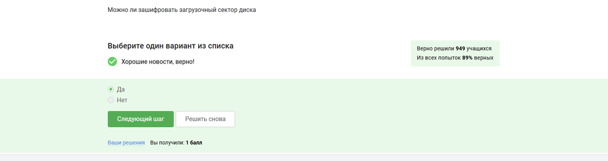

Шифрование загрузочного сектора

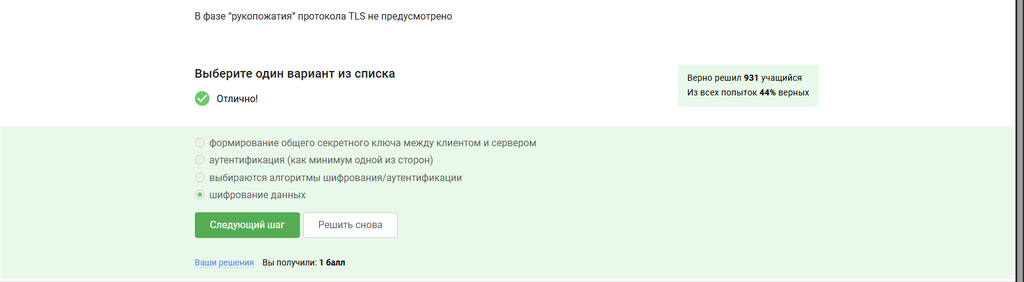

В видеолекции было рассказано, какие программы можно использовать для шифрования жесткого диска (рис. 3 [-@fig:003]).

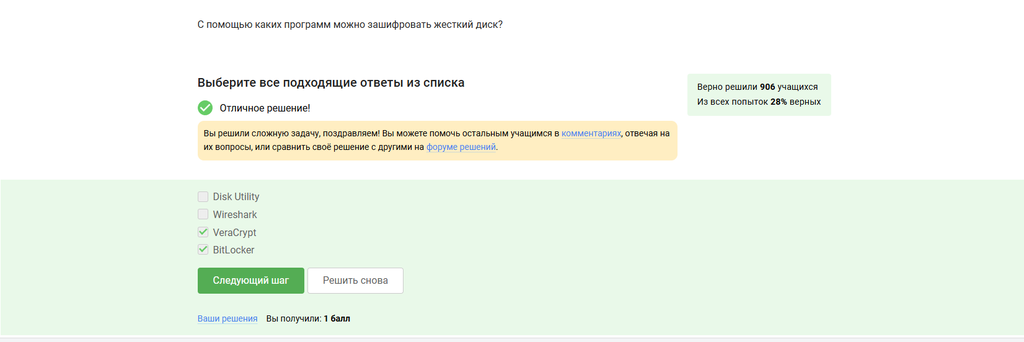

Программы шифрования

# Выполнение блока 2 (Пароли)

В видеолекции было рассказано, какие пароли считаются простыми, а какие стойкими (рис. 4 [-@fig:004]).

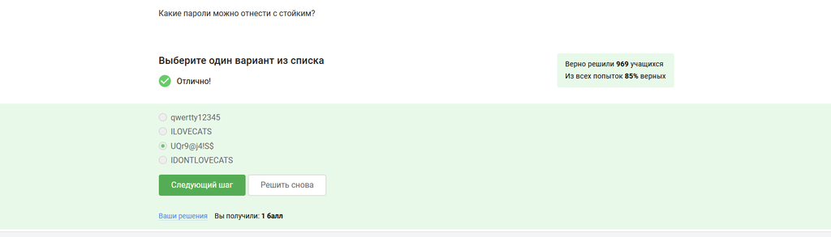

Стойкие пароли

В видеолекции было сказано, что лучше хранить сложные пароли в менеджерах паролей, запомнив всего один пароль от менеджера (рис. 5 [-@fig:005]).

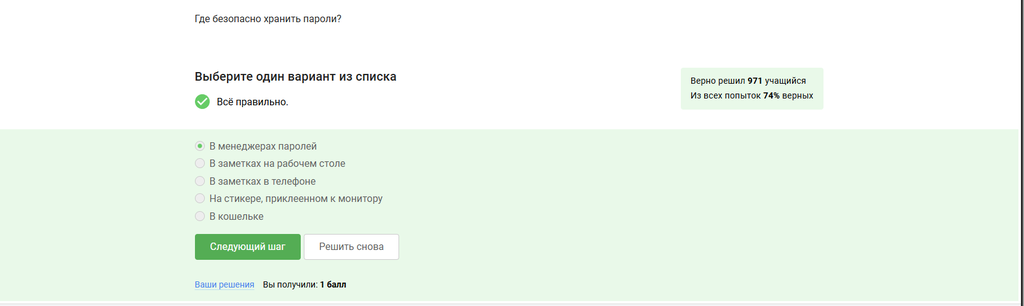

Где хранить пароли

В видеолекции было рассказано, для чего нужна капча (рис. 6 [-@fig:006]).

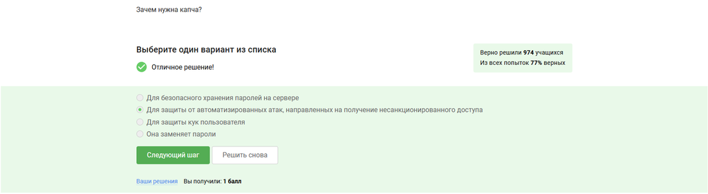

Для чего нужна капча

В видеолекции было рассказано, для чего нужно хеширование паролей (рис. 7 [-@fig:007]).

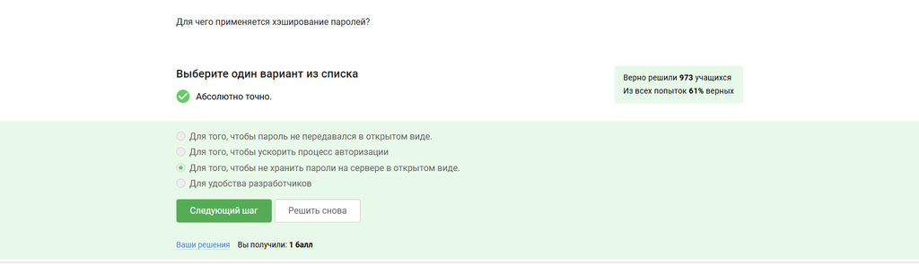

Хеширование паролей

В видеолекции было сказано, что если злоумышленник получил доступ к серверу, уже ничто не поможет (рис. 8 [-@fig:008]).

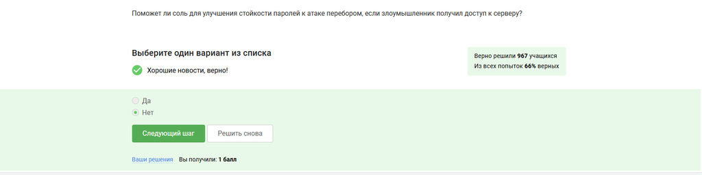

Соль

В видеолекции было рассказано, что что может помочь от атаки перебором (рис. 9 [-@fig:009]).

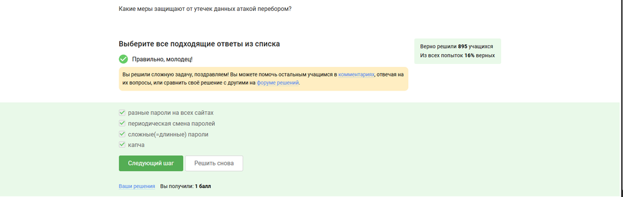

Атака перебором

# Выполнение блока 3 (Фишинг)

В видеолекции было рассказано, на что стоит обратить внимание в адресной строке, чтоб определить является ли сайт/ссылка фишинговыми (рис. 10 [-@fig:010]).

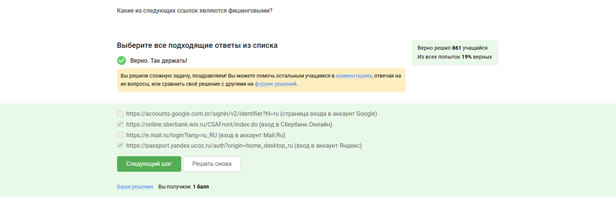

Фишинговая ссылка

В видеолекции было сказано, существует способ подмены, что фишинговый имейл приходит от знакомого адреса (рис. 11 [-@fig:011]).

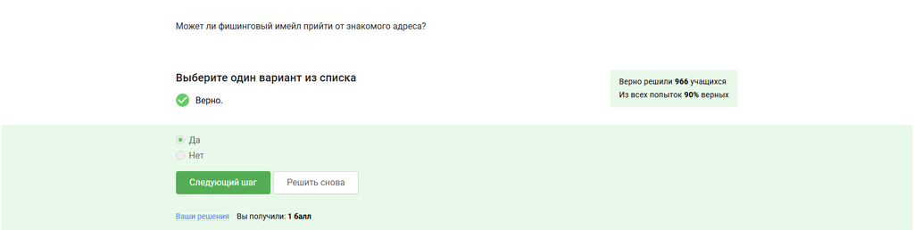

Подмена адреса

# Выполнение блока 4 (Вирусы)

В видеолекции было сказано, что такое спуфинг (рис. 12 [-@fig:012]).

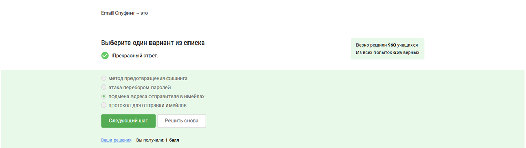

Спуфинг

В видеолекции было сказано, что такое троян (рис. 13 [-@fig:013]).

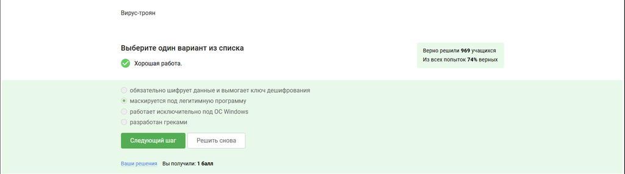

Троян

# Выполнение блока 5 (Безопасность мессенджеров)

В видеолекции было сказано, что ключ шифрования в мессенджере Signal формируется на этапе генерации первого сообщения стороной отправителем (рис. 14 [-@fig:014]).

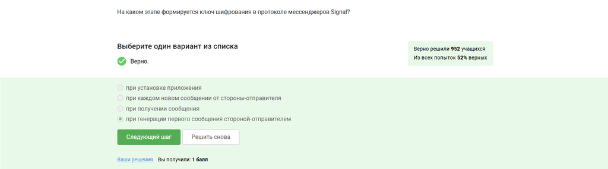

Signal

В видеолекции было сказано, кому известен ip-aдрес получателя (рис. 15 [-@fig:015]).

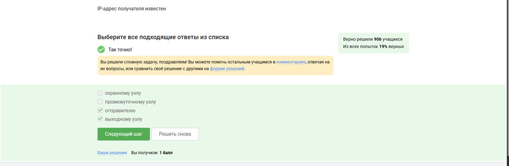

Кому известен IP адрес получателя

В видеолекции было сказано, что суть сквозного шифрования состоит в том, что сообщения передаются по узлам связи в зашифрованном фиде (рис. 16 [-@fig:016]).

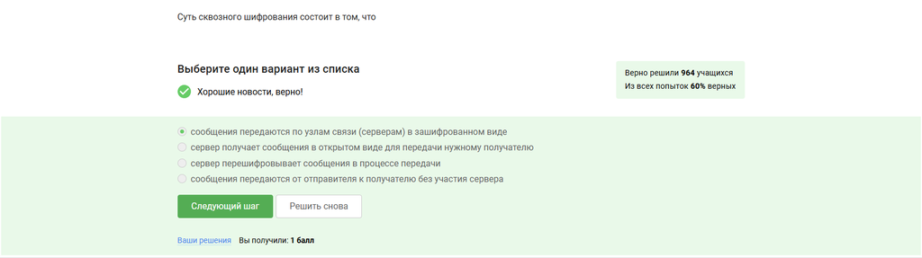

Сквозное шифрование

# Выводы

Получил полезные знания и прошел тесты по теме защита ПК/телефона